# Анализ поведения пользователей мобильного приложения «Ненужные вещи»

У нас имееются данные в двух датасетах по которым необходимо сделать анализ поведения пользователей мобильного приложения «Ненужные вещи».

Необходимо будет проанализировать связь целевого события — **просмотра контактов** — и других действий пользователей. Оценить какие действия чаще совершались и провести исследовательский анализ данных.

Ответим на 2 основных вопроса исследования, а именно:  
1.Проанализируем связь целевого события —*просмотра контактов* — и других действий пользователей:  
-В разрезе сессий отобрем сценарии\паттерны, которые приводят к просмотру контактов  
-Построим воронки по основным сценариям в разрезе уникальных пользователей  
2.Оценим, какие действия чаще совершают те пользователи, которые просматривают контакты:  
Рассчитаем относительную частоту событий в разрезе двух групп пользователей:  
-группа пользователей, которые смотрели контакты contacts_show  
-группа пользователей, которые не смотрели контакты contacts_show

Необходимо будет проверить 2 гипотезы:  
**Первая гипотеза:**  
Конверсия в просмотры контактов может быть различной между пользователями, которые совершают действия tips_show и tips_click, и пользователями, которые совершают только действие tips_show.  
*H0 (нулевая гипотеза)*: Конверсия в просмотры контактов одинакова у пользователей, которые совершают действия tips_show и tips_click, и у пользователей, которые совершают только действие tips_show.  
*H1 (альтернативная гипотеза)*: Конверсия в просмотры контактов различается у пользователей, которые совершают действия tips_show и tips_click, и у пользователей, которые совершают только действие tips_show.  
**Вторая гипотеза:**  
Конверсия в просмотры контактов (по действиям tips_show и tips_click) у пользователей, пришедших с сервиса Yandex, выше, чем у пользователей, пришедших с других сервисов.  
*H0 (нулевая гипотеза)*: Конверсия в просмотры контактов одинакова у пользователей, пришедших с сервиса Yandex, и у пользователей, пришедших с других сервисов.  
*H1 (альтернативная гипотеза)*: Конверсия в просмотры контактов выше у пользователей, пришедших с сервиса Yandex, по сравнению с пользователями, пришедшими с других сервисов.

**ЦЕЛЬ ПРОЕКТА:** Анализ поведения пользователей и также получить на основе поведения пользователей гипотезы о том как можно было бы улучшить приложение с точки зрения пользовательского опыта

Шаги проекта:  
**Шаг 1. Предобработка данных**  
1.1.Загрузка данных.  
1.2 Изучим общую информацию о датафреймах  
1.3 Предобработка данных  
1.4.Обработка дубликатов  
1.5.Создание новых столбцов для анализа  
1.6.Обработка одинаковых событий в данных  
**Шаг 2. Исследовательский анализ данных**  
2.1.Количество событий и пользователей в данных  
2.2.Среднее количество событий на пользователя  
2.3.Анализ c помощью каких сервисов пользователи пришли в мобильное приложение  
2.3.Анализ данных за период  
2.4.Анализ событий в мобильном приложении  
2.5.Анализ сессий пользователей  
2.6.Анализ конверсий  
2.7.Анализ показателей DAU  
2.8.Анализ retention rate  
**Шаг 3. Основные вопросы исследования**  
3.1.Анализ связи целевого события просмотра контактов к другим действиям пользователей:  
*Анализ сессий которые приводят к событию просмотру контактов*  
*Анализ воронок по основным сценариям в разрезе уникальных пользователей*  
3.2. Расчет и сравнение относительной частоты событий между двумя группами пользователей:  
*1 группа пользователей, которые смотрели контакты contacts_show*  
*2 группа пользователей, которые не смотрели контакты contacts_show*  
**Шаг 4. Проверка гипотез**  
4.1 Проверка гипотезы 1  
4.2. Проверка гипотезы 2  
**Шаг 5. Выводы**

#### Шаг 1. Загрузка и предобработка данных.

**1.1.Загрузка данных.** На данном этапе загрузили файл csv формата и библиотеки

```python
import pandas as pd
import matplotlib.pyplot as plt
import datetime as dt
from datetime import datetime, timedelta
import seaborn as sns
import plotly.express as px
import numpy as np
import requests #диаграмма санкей
from tqdm import tqdm #диаграмма санкей
import plotly.graph_objects as go #диаграмма санкей
from scipy import stats as st
from statsmodels.stats.proportion import proportions_ztest
```

```python
try:
    source = pd.read_csv('C:\\Users\\DILYA\\Downloads\\Practicum\\data\\mobile_sources.csv')
    data = pd.read_csv('C:\\Users\\DILYA\\Downloads\\Practicum\\data\\mobile_dataset.csv')
except:
    source = pd.read_csv('https://code.s3.yandex.net//datasets/mobile_sources.csv')
    data = pd.read_csv('https://code.s3.yandex.net//datasets/mobile_dataset.csv')
#загрузка данных
```

**1.2 Выведим первые 5 строк набора данных. Изучим общую информацию о датафреймах**

```python
source.head(5)
```

|  | userId | source |
| --- | --- | --- |
| 0 | 020292ab-89bc-4156-9acf-68bc2783f894 | other |
| 1 | cf7eda61-9349-469f-ac27-e5b6f5ec475c | yandex |
| 2 | 8c356c42-3ba9-4cb6-80b8-3f868d0192c3 | yandex |
| 3 | d9b06b47-0f36-419b-bbb0-3533e582a6cb | other |
| 4 | f32e1e2a-3027-4693-b793-b7b3ff274439 | google |

```python
source.info()
display(f"Объем данных: {source.shape}")
```

```
<class 'pandas.core.frame.DataFrame'>
RangeIndex: 4293 entries, 0 to 4292
Data columns (total 2 columns):
 #   Column  Non-Null Count  Dtype
---  ------  --------------  -----
 0   userId  4293 non-null   object
 1   source  4293 non-null   object
dtypes: object(2)
memory usage: 67.2+ KB
```

```
'Объем данных: (4293, 2)'
```

```python
unique_source = source['source'].unique()
display(unique_source)
```

```
array(['other', 'yandex', 'google'], dtype=object)
```

В данных имеется два столбца:  
userId — идентификатор пользователя,  
source — источник, с которого пользователь установил приложение.Всего таких источника три: 'other', 'yandex', 'google' Всего 4293 записи.

```python
data.head(5)
```

|  | event.time | event.name | user.id |
| --- | --- | --- | --- |
| 0 | 2019-10-07 00:00:00.431357 | advert_open | 020292ab-89bc-4156-9acf-68bc2783f894 |
| 1 | 2019-10-07 00:00:01.236320 | tips_show | 020292ab-89bc-4156-9acf-68bc2783f894 |
| 2 | 2019-10-07 00:00:02.245341 | tips_show | cf7eda61-9349-469f-ac27-e5b6f5ec475c |
| 3 | 2019-10-07 00:00:07.039334 | tips_show | 020292ab-89bc-4156-9acf-68bc2783f894 |
| 4 | 2019-10-07 00:00:56.319813 | advert_open | cf7eda61-9349-469f-ac27-e5b6f5ec475c |

```python
data.info()
display(f"Объем данных: {data.shape}")
```

```
<class 'pandas.core.frame.DataFrame'>
RangeIndex: 74197 entries, 0 to 74196
Data columns (total 3 columns):
 #   Column      Non-Null Count  Dtype
---  ------      --------------  -----
 0   event.time  74197 non-null  object
 1   event.name  74197 non-null  object
 2   user.id     74197 non-null  object
dtypes: object(3)
memory usage: 1.7+ MB
```

```
'Объем данных: (74197, 3)'
```

```python
unique_event = data['event.name'].unique()
display(unique_event)
```

```
array(['advert_open', 'tips_show', 'map', 'contacts_show', 'search_4',
       'search_5', 'tips_click', 'photos_show', 'search_1', 'search_2',
       'search_3', 'favorites_add', 'contacts_call', 'search_6',
       'search_7', 'show_contacts'], dtype=object)
```

В данных имеется три столбца:  
**event.time** — время совершения,  
**user.id** — идентификатор пользователя,  
**event.name** — действие пользователя.  
Виды действий:  
*advert_open* — открыл карточки объявления,  
*photos_show* — просмотрел фотографий в объявлении,  
*tips_show* — увидел рекомендованные объявления,  
*tips_click* — кликнул по рекомендованному объявлению,  
*contacts_show и show_contacts* — посмотрел номер телефона,  
*contacts_call* — позвонил по номеру из объявления,  
*map* — открыл карту объявлений,  
*search_1 — search_7* — разные действия, связанные с поиском по сайту,  
*favorites_add* — добавил объявление в избранное  
Каждая запись — это действие пользователя, или событие В шаге обработка данных заменим название столбцов так как они не совсем удобны для чтения информация и агрерирования кода, так же объединим show_contacts и contacts_show т.к это одно и тоже  
Изучим можно ли объединить search_1 — search_7 в одно событие

**1.3 Предобработка данных**

Для начала поменяем название столбцов для удобвства в дальнейшем использовании.

```python
source = source.rename(columns={'userId': 'user_id',})
source.head(5)
```

|  | user_id | source |
| --- | --- | --- |
| 0 | 020292ab-89bc-4156-9acf-68bc2783f894 | other |
| 1 | cf7eda61-9349-469f-ac27-e5b6f5ec475c | yandex |
| 2 | 8c356c42-3ba9-4cb6-80b8-3f868d0192c3 | yandex |
| 3 | d9b06b47-0f36-419b-bbb0-3533e582a6cb | other |
| 4 | f32e1e2a-3027-4693-b793-b7b3ff274439 | google |

```python
data = data.rename(columns={
    'event.time': 'event_time',
    'event.name': 'event_name',
    'user.id': 'user_id',
})
data.head(5)
```

|  | event_time | event_name | user_id |
| --- | --- | --- | --- |
| 0 | 2019-10-07 00:00:00.431357 | advert_open | 020292ab-89bc-4156-9acf-68bc2783f894 |
| 1 | 2019-10-07 00:00:01.236320 | tips_show | 020292ab-89bc-4156-9acf-68bc2783f894 |
| 2 | 2019-10-07 00:00:02.245341 | tips_show | cf7eda61-9349-469f-ac27-e5b6f5ec475c |
| 3 | 2019-10-07 00:00:07.039334 | tips_show | 020292ab-89bc-4156-9acf-68bc2783f894 |
| 4 | 2019-10-07 00:00:56.319813 | advert_open | cf7eda61-9349-469f-ac27-e5b6f5ec475c |

Сменили названия для более удобный формат, производя замену в названиях с точки на нижний регистр

**1.4.Обработка дубликатов**

```python
# кол-во дубликатов во всем датафрейме
data_duplicates = data.duplicated().sum()
print("Количество дубликатов в датафрейме data:", data_duplicates)
```

```
Количество дубликатов в датафрейме data: 0
```

```python
# кол-во дубликатов во всем датафрейме
source_duplicates = source.duplicated().sum()
print("Количество дубликатов в датафрейме source:", source_duplicates)
```

```
Количество дубликатов в датафрейме source: 0
```

Проверили оба датафрейма явных дубликатов не обнаружено

**1.5.Создание новых столбцов для анализа**

Для будущих вычесление необходимо из столбца event_time изъять столбцы с датой и времени, а также отдельный столбец дат

```python
data['event_time'] = pd.to_datetime(data['event_time'], utc=True)
data['date'] = data['event_time'].dt.date
data['time'] = data['event_time'].dt.strftime('%H:%M:%S')
data.head(5)
```

|  | event_time | event_name | user_id | date | time |
| --- | --- | --- | --- | --- | --- |
| 0 | 2019-10-07 00:00:00.431357+00:00 | advert_open | 020292ab-89bc-4156-9acf-68bc2783f894 | 2019-10-07 | 00:00:00 |
| 1 | 2019-10-07 00:00:01.236320+00:00 | tips_show | 020292ab-89bc-4156-9acf-68bc2783f894 | 2019-10-07 | 00:00:01 |
| 2 | 2019-10-07 00:00:02.245341+00:00 | tips_show | cf7eda61-9349-469f-ac27-e5b6f5ec475c | 2019-10-07 | 00:00:02 |
| 3 | 2019-10-07 00:00:07.039334+00:00 | tips_show | 020292ab-89bc-4156-9acf-68bc2783f894 | 2019-10-07 | 00:00:07 |
| 4 | 2019-10-07 00:00:56.319813+00:00 | advert_open | cf7eda61-9349-469f-ac27-e5b6f5ec475c | 2019-10-07 | 00:00:56 |

Создали два столбца отдельных с датой и временем, при этом были микросекунда, оставили время только до секунд

**1.6.Обработка одинаковых событий в данных**

В данных data есть два одинаковых действия contacts_show и show_contacts — посмотрел номер телефона, объедим их в одно действие Так же все поисковые запросы объединим в одно действие search т.к мы не знаем в чем их принципиальное различие между друг другом и от этого качество анализа не пострадает

```python
# заменяем значения 'contacts_show' на 'show_contacts' в столбце 'event_name'
data['event_name'] = data['event_name'].replace('contacts_show', 'show_contacts')
data['event_name'] = data['event_name'].str.replace('search_\d', 'search', regex=True)
unique_event_names = data['event_name'].unique()
print(unique_event_names)
```

```
['advert_open' 'tips_show' 'map' 'show_contacts' 'search' 'tips_click'
 'photos_show' 'favorites_add' 'contacts_call']
```

Проверили замену и проверим нет ли теперь одинаковых событий в данных

```python
data_duplicates = data.duplicated().sum()
print("Количество дубликатов в датафрейме data:", data_duplicates)
```

```
Количество дубликатов в датафрейме data: 0
```

В первом шаге были изучены данные, произвели смену названий столбцов на нижний регистр. Добавили необходимые столбцы с датами для дальнейшего изучения данных. Проверили данные на дубликаты. Приступаем вк следующему шагу в анализе данных

#### Шаг 2. Исследовательский анализ данных

В данном шаге узнаем:  
Количество событий и пользователей в данных,  
Среднее количество событий на пользователя.  
Данными за какой период располагаем, построим воронки  
Так же устновим длительность сессий для каждого пользователя (среднее число и т.д)

**2.1.Количество событий и пользователей в данных**

```python
num_rows = data.shape[0]
unique_user = data['user_id'].nunique()
print("Общее кол-во событий:", num_rows)
print("Пользователей в логе:", unique_user)
```

```
Общее кол-во событий: 74197
Пользователей в логе: 4293
```

Итого получается что 74 197 событий в данных и 4 293 уникальных пользователей

**2.2. Среднее количество событий на пользователя**

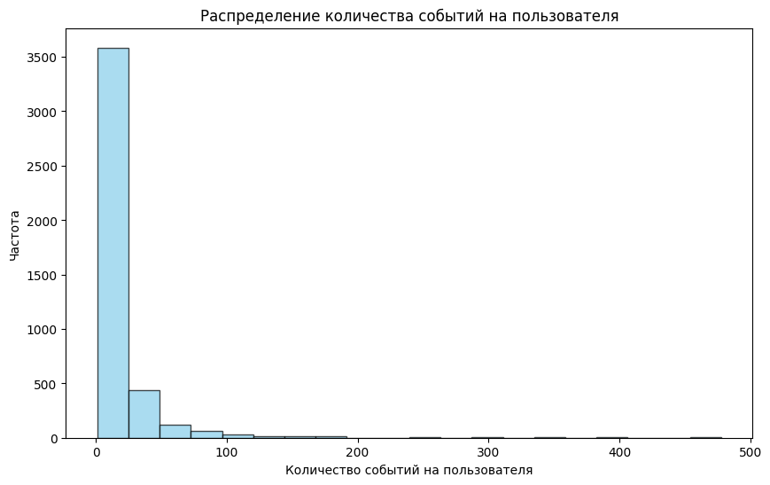

```
Среднее количество событий на пользователя: 17.28
count    4293.000000
mean       17.283252
std        29.130677
min         1.000000
25%         5.000000
50%         9.000000
75%        17.000000
max       478.000000
Name: event_name, dtype: float64
```

```python
average_events_per_user = round(data.groupby('user_id')['event_name'].count().mean(),2)
event_counts_per_user = data.groupby('user_id')['event_name'].count()

# Построение гистограммы
plt.figure(figsize=(10, 6))
plt.hist(event_counts_per_user, bins=20, color='skyblue', edgecolor='black', alpha=0.7)
plt.xlabel('Количество событий на пользователя')
plt.ylabel('Частота')
plt.title('Распределение количества событий на пользователя')
plt.show()

print("Среднее количество событий на пользователя:", average_events_per_user)
print(event_counts_per_user.describe())
```

В среднем одного пользователя приходится 17.28 события

Стандартное отклонение (std): Стандартное отклонение равно примерно 29.13. Это указывает на разброс данных относительно среднего значения. Большое стандартное отклонение говорит о том, что значения сильно разбросаны вокруг среднего.  
Минимальное количество событий, совершенных одним пользователем, составляет 1, а максимальное количество событий - 478.  
Квартили (25%, 50%, 75%): 25% пользователей совершают 5 или менее событий, 50% пользователей совершают 9 или менее событий, и 75% пользователей совершают 17 или менее событий.  
Из этого можно сделать вывод, что у большинства пользователей наблюдается небольшое количество событий, но есть небольшой процент пользователей, которые совершают значительно больше событий, что приводит к высокому среднему значению и большому стандартному отклонению.

**2.3.Анализ c помощью каких сервисов пользователи пришли в мобильное приложение**

Рассмотрим c помощью каких сервисов пользователи пришли в мобильное приложение

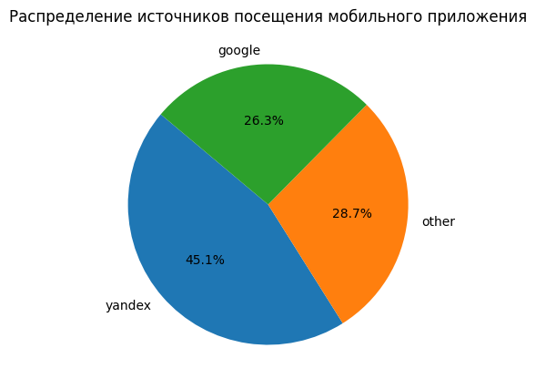

```python
# получение данных о распределении источников
source_distribution = source['source'].value_counts()

# построение круговой диаграммы
plt.figure(figsize=(5, 5))
plt.pie(source_distribution, labels=source_distribution.index, autopct='%1.1f%%', startangle=140)
plt.title('Распределение источников посещения мобильного приложения')
plt.show()
```

Получается что в основном все заходы в приложения по событиям происходят через yandex - 45.1%, затем следует Other c весом 28,7% на последнем месте Google с весом 26,3%

**2.4.Анализ данных за период**

Расссмотрим за какой период у нас имеются данные, а так же посмторим распределение событий по дням

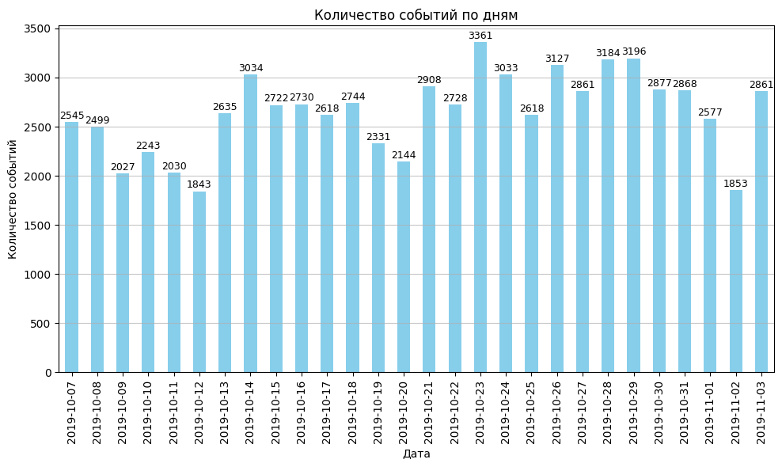

```
Минимальная дата: 2019-10-07
Максимальная дата: 2019-11-03
```

```python
#датафрейм по датам
events_by_date = data.groupby('date')['event_name'].count()

# построение столбчатой диаграммы
plt.figure(figsize=(10, 6))
events_by_date.plot(kind='bar', color='skyblue')
plt.title('Распределение событий по датам')
plt.xlabel('Дата')
plt.ylabel('Количество событий')
plt.xticks()
plt.grid(axis='y', alpha=0.7)


# добавление значений на столбцы
for i, count in enumerate(events_by_date):
    plt.text(i, count + 10, str(count), ha='center', va='bottom', fontsize=9)

plt.title('Количество событий по дням')
plt.xlabel('Дата')
plt.ylabel('Количество событий')

plt.tight_layout()
plt.show()

min_date = data['date'].min()
max_date = data['date'].max()
print("Минимальная дата:", min_date)
print("Максимальная дата:", max_date)
```

У нас имеются данные начиная с 07 октября 2019 по 03 ноября 2019. Самвй пиковый день по количествам событий является 23 октября 2019 года с количеством событий 3361, меньше всего же посещали приложение пользователи 12 октября 2019 было совершено только 1843 события в приложении.  
Теперь посмотрим хитмеп для изучения распределение каждого события по дням.

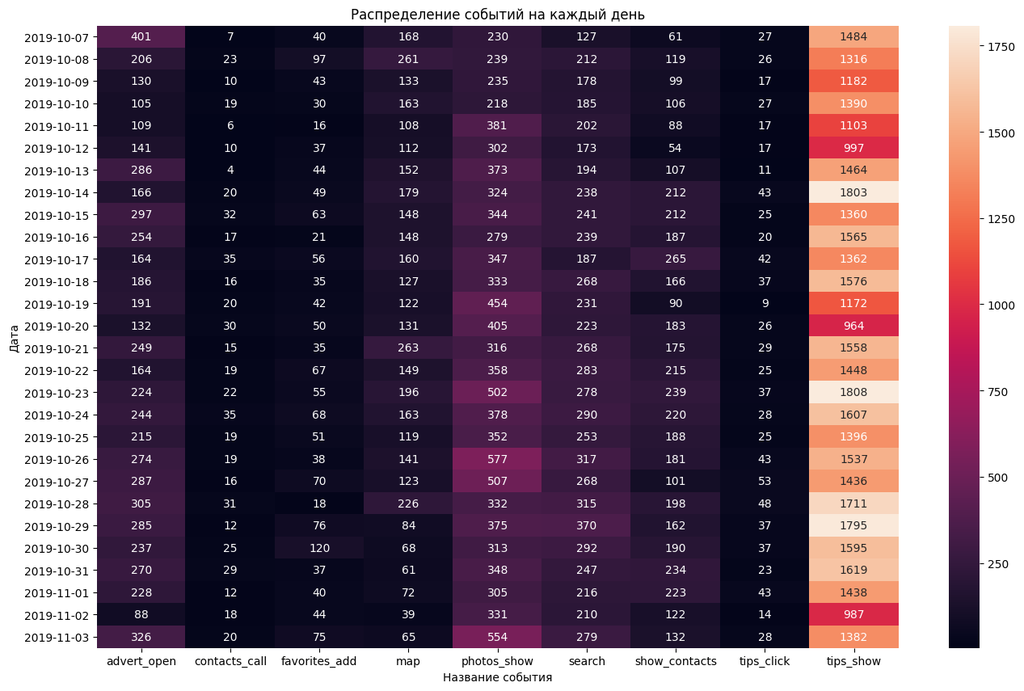

```python
#таблица распределения событию в день
events_data = data.pivot_table(index='date', columns='event_name', values='time', aggfunc='count')
plt.figure(figsize=(16,10))
plt.title('Распределение событий на каждый день')
sns.heatmap(events_data, annot=True, fmt='', square=False);
plt.xlabel('Название события')
plt.ylabel('Дата')
plt.show()
```

Однозначно видно что самое популярное событие tips_show (увидел рекомендованные объявления) и однозначно будет во главе воронки событий. Но это всего лишь просмотр рекомендованноего объявления данное действие не совершает пользователь. Необходимо посмтореть хитмеп без данного действия для лучшего анализа.

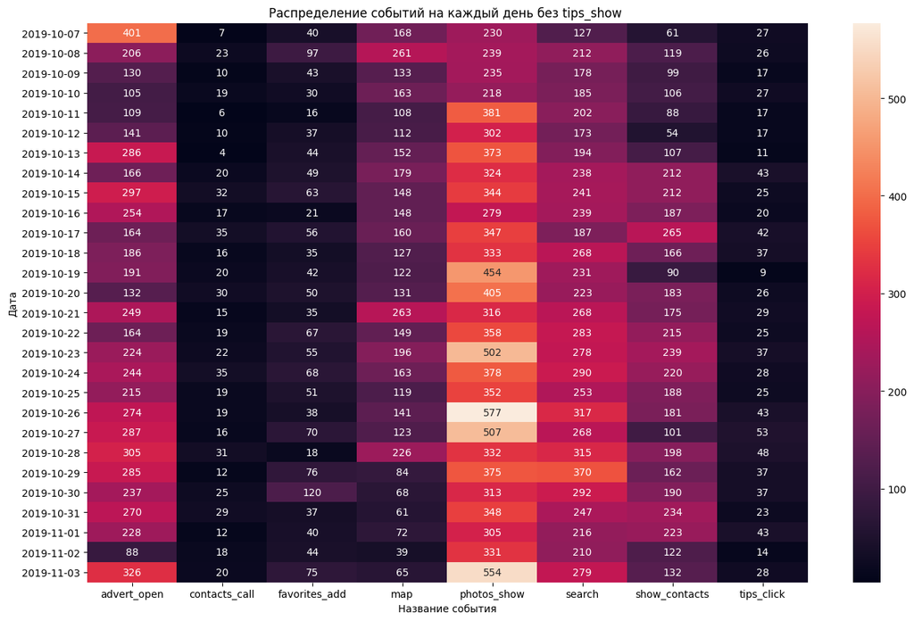

```python
# удаляем столбец с действием tips_show
events_data.drop(columns='tips_show', inplace=True)

# построение тепловой карты
plt.figure(figsize=(16,10))
plt.title('Распределение событий на каждый день без tips_show ')
sns.heatmap(events_data, annot=True, fmt='', square=False)
plt.xlabel('Название события')
plt.ylabel('Дата')
plt.show()
```

**2.4.Анализ событий в мобильном приложении**

В данном пункте проанализируем частоту событий пользователями в мобильном приложении

```python
# получаем количество событий
event_counts = data['event_name'].value_counts().reset_index()
event_counts.columns = ['event_name', 'count']

# получаем вес каждого события
event_weights = round((data['event_name'].value_counts(normalize=True) * 100).reset_index(),2)
event_weights.columns = ['event_name', 'weight,%']

# объединяем таблицы по столбцу 'event_name'
event_result = pd.concat([event_counts, event_weights['weight,%']], axis=1)
display(event_result)
```

|  | event_name | count | weight,% |
| --- | --- | --- | --- |
| 0 | tips_show | 40055 | 53.98 |
| 1 | photos_show | 10012 | 13.49 |
| 2 | search | 6784 | 9.14 |
| 3 | advert_open | 6164 | 8.31 |
| 4 | show_contacts | 4529 | 6.10 |
| 5 | map | 3881 | 5.23 |
| 6 | favorites_add | 1417 | 1.91 |
| 7 | tips_click | 814 | 1.10 |
| 8 | contacts_call | 541 | 0.73 |

Исходя из этих данных, можно сделать вывод о том, событие tips_show может считаться ключевым для анализа взаимодействия пользователей с рекомендованными объявлениями. Так же возможно есть закономерность прежде чем звонить продавцу объявления потенциальный покупатель сначала просмотрит георгафическое расположение объявления.  
Теперь посмотрим сколько пользователей совершали каждое из этих событий

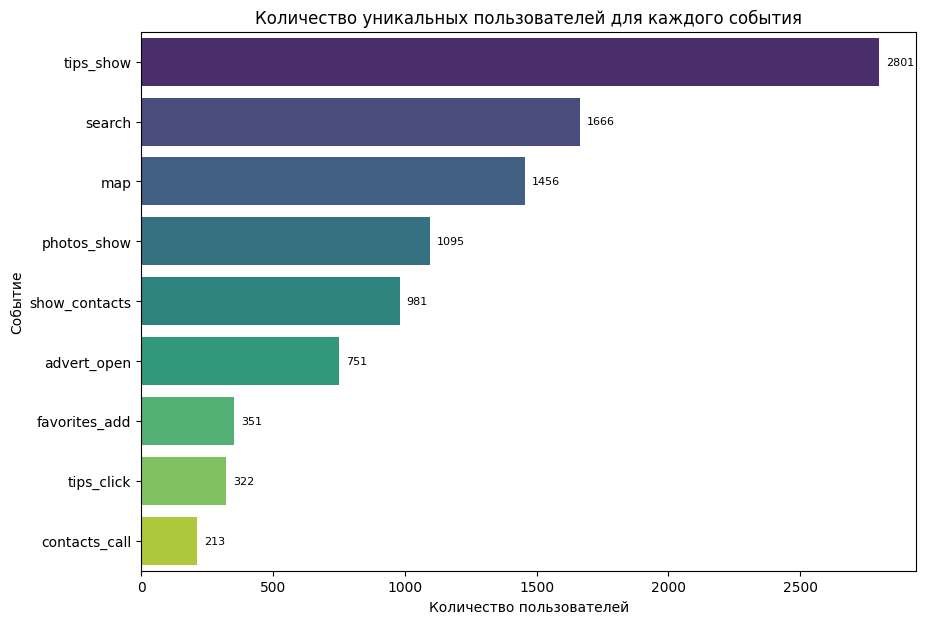

```python
# получаем количество событий по пользователям
users_per_event = data.groupby('event_name')['user_id'].nunique().reset_index()
users_per_event.columns = ['event_name', 'total_user']
users_per_event['ratio,%'] = round((users_per_event['total_user'] / len(data['user_id'].unique()) * 100),2)
users_result = users_per_event.sort_values(by='ratio,%', ascending=False)

# построение гистограммы
plt.figure(figsize=(10, 7))
ax = sns.barplot(x='total_user', y='event_name', data=users_result, palette='viridis')

# добавление значений над столбцами
for p in ax.patches:
    ax.annotate(f'{p.get_width():.0f}',
                (p.get_width(), p.get_y() + p.get_height() / 2),
                ha='left', va='center', xytext=(5, 0),
                textcoords='offset points', fontsize=8)

plt.title('Количество уникальных пользователей для каждого события')
plt.xlabel('Количество пользователей')
plt.ylabel('Событие')
plt.show()
```

Из предоставленных данных о количестве уникальных пользователей по событиям можно сделать следующие выводы:

**tips_show (увидел рекомендованные объявления)** имеет самое большое количество уникальных пользователей (2801), что составляет примерно 65.25% от общего числа уникальных пользователей.  
**search (поиск по сайту)** следующий по числу уникальных пользователей среди событий, с 1666 пользователями, что составляет примерно 38.81% от общего числа.  
**map (просмотр карты объявления)** и **photos_show (просмотр фотографий в объявлении)** также имеют существенное количество уникальных пользователей, составляя 1456 (33.92%) и 1095 (25.51%) соответственно.  
**show_contacts (посмотр номера телефона)** имеет 981 уникального пользователя (22.85%), что указывает на значительную долю пользователей, которые просматривают контакты.  
**advert_open (открытие карточки объявления)**, **favorites_add (добавил объявление в избранное)**, **tips_click (клик по рекомендованному объявлению)** и **contacts_call (звонок по номеру из объявления)** имеют меньшее количество уникальных пользователей, каждый из которых составляет менее 18% от общего числа пользователей.

**2.5.Анализ сессий пользователей**

Для того чтобы провести дальнейший анализ и выявить сценарии\паттерны, которые приводят к просмотру контактов необходимо создать новый столбец по сессиям, для этого создадим новый столбец session_id и посмотрим на длительность сессий пользователей

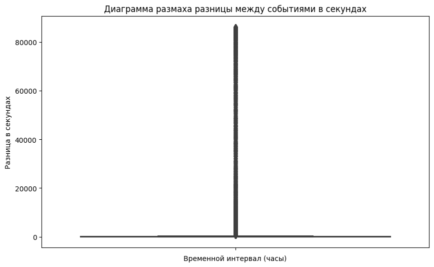

```python
# сортировка data по user_id и event_time
data_sorted = data.sort_values(by=['user_id', 'event_time'])

# подсчет разницы во времени между событиями для каждого пользователя
data_sorted['time_diff'] = data_sorted.groupby('user_id')['event_time'].diff()

# переведем столбец из timedelta в дату и время
data_sorted['time_diff'] = data_sorted['time_diff'].dt.seconds

# построение диаграмму размаха для разницы между событиями
plt.figure(figsize=(10, 6))
sns.boxplot(data=data_sorted, y='time_diff')
plt.title('Диаграмма размаха разницы между событиями в секундах')
plt.xlabel('Временной интервал (часы)')
plt.ylabel('Разница в секундах')
plt.show()
```

На графике видно, что между большинством событий в рамках суток промежуток очень маленький, остальные данные являются выбросами.ожно предположить, что скорее всего длительное время сессий исходит из ого что приложение уходит в фоновой режим когда закладка не закрывается на телефонах  
Построим тот же самый график с ограничением на диапазон значений вертикальной оси, чтобы рассмотреть распределение данных.

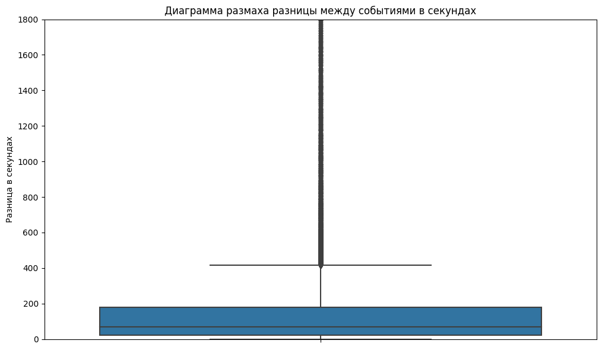

```python
# построим диаграмму размаха с ограничением на вертикальную ось
plt.figure(figsize=(12,7))
sns.boxplot(data=data_sorted, y='time_diff')
plt.ylabel('Разница в секундах')
plt.title('Диаграмма размаха разницы между событиями в секундах')
plt.ylim((0,1800))
plt.show()
```

```python
# преобразование столбца 'event_time' в формат datetime в отсортированной таблице data_sorted
data_sorted['event_time'] = pd.to_datetime(data_sorted['event_time'])

# определение разницы в 7 минут для каждой группы с накопительной суммой
g = (data_sorted.groupby('user_id')['event_time'].diff() > pd.Timedelta('7Min')).cumsum()

# создание счетчика групп
data_sorted['session_id'] = data_sorted.groupby(['user_id', g], sort=False).ngroup() + 1
display(data_sorted)
```

|  | event_time | event_name | user_id | date | time | time_diff | session_id |
| --- | --- | --- | --- | --- | --- | --- | --- |
| 805 | 2019-10-07 13:39:45.989359+00:00 | tips_show | 0001b1d5-b74a-4cbf-aeb0-7df5947bf349 | 2019-10-07 | 13:39:45 | NaN | 1 |
| 806 | 2019-10-07 13:40:31.052909+00:00 | tips_show | 0001b1d5-b74a-4cbf-aeb0-7df5947bf349 | 2019-10-07 | 13:40:31 | 45.0 | 1 |
| 809 | 2019-10-07 13:41:05.722489+00:00 | tips_show | 0001b1d5-b74a-4cbf-aeb0-7df5947bf349 | 2019-10-07 | 13:41:05 | 34.0 | 1 |
| 820 | 2019-10-07 13:43:20.735461+00:00 | tips_show | 0001b1d5-b74a-4cbf-aeb0-7df5947bf349 | 2019-10-07 | 13:43:20 | 135.0 | 1 |
| 830 | 2019-10-07 13:45:30.917502+00:00 | tips_show | 0001b1d5-b74a-4cbf-aeb0-7df5947bf349 | 2019-10-07 | 13:45:30 | 130.0 | 1 |
| ... | ... | ... | ... | ... | ... | ... | ... |
| 72584 | 2019-11-03 15:51:23.959572+00:00 | tips_show | fffb9e79-b927-4dbb-9b48-7fd09b23a62b | 2019-11-03 | 15:51:23 | 27.0 | 14166 |
| 72589 | 2019-11-03 15:51:57.899997+00:00 | show_contacts | fffb9e79-b927-4dbb-9b48-7fd09b23a62b | 2019-11-03 | 15:51:57 | 33.0 | 14166 |
| 72684 | 2019-11-03 16:07:40.932077+00:00 | tips_show | fffb9e79-b927-4dbb-9b48-7fd09b23a62b | 2019-11-03 | 16:07:40 | 943.0 | 14167 |
| 72688 | 2019-11-03 16:08:18.202734+00:00 | tips_show | fffb9e79-b927-4dbb-9b48-7fd09b23a62b | 2019-11-03 | 16:08:18 | 37.0 | 14167 |
| 72689 | 2019-11-03 16:08:25.388712+00:00 | tips_show | fffb9e79-b927-4dbb-9b48-7fd09b23a62b | 2019-11-03 | 16:08:25 | 7.0 | 14167 |

74197 rows × 7 columns

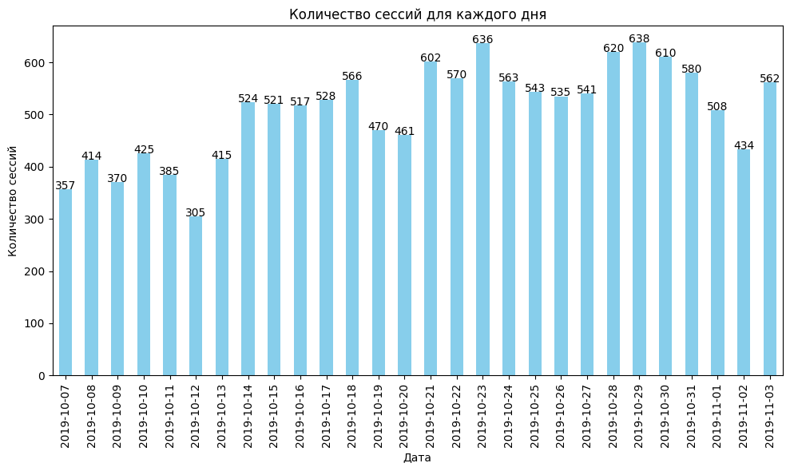

```
Общее число сессий: 14167
```

```python
# подсчет числа сессий для каждого дня
sessions_per_day = data_sorted.groupby('date')['session_id'].nunique()

# построение графика
plt.figure(figsize=(10, 6))
sessions_per_day.plot(kind='bar',color='skyblue')
plt.xlabel('Дата')
plt.ylabel('Количество сессий')
plt.title('Количество сессий для каждого дня')
plt.xticks()
plt.tight_layout()

# добавление подписей с количеством значений
for i, value in enumerate(sessions_per_day):
    plt.text(i, value + 0.1, str(value), ha='center')

plt.show()

# подсчет общего числа сессий
total_sessions = data_sorted['session_id'].nunique()
print("Общее число сессий:", total_sessions)
```

**2.6.Анализ конверсий**

Рассмотрим конверсию целевого события — просмотра контактов (show_contacts) и tips_click (клик по рекомендованному объявлению)

```python
# общее количество уникальных пользователей
total_users = data_sorted['user_id'].nunique()

# количество пользователей, которые просмотрели событие "contact_show"
users_viewed_contact_show = data_sorted[data_sorted['event_name'] == 'show_contacts']['user_id'].nunique()

# количество пользователей, которые просмотрели событие "tips_show"
users_viewed_tips_click = data_sorted[data_sorted['event_name'] == 'tips_click']['user_id'].nunique()

# рассчёт конверсии
conversion_rate_tips_click = (users_viewed_tips_click / total_users) * 100
conversion_rate_contact_show = (users_viewed_contact_show / total_users) * 100

print("Конверсия для события 'tips_click': {:.2f}%".format(conversion_rate_tips_click))
print("Конверсия для события 'contact_show': {:.2f}%".format(conversion_rate_contact_show))
```

```
Конверсия для события 'tips_click': 7.50%
Конверсия для события 'contact_show': 22.85%
```

Конверсия пользователей, дошедших к просмотру контактов (contact_show) составила 22,85% в целом весьма не плохой показатель, а вот конверсия по tips_click (клик по рекомендованному объявлению) составила всего лишь 7,50%

**2.7.Анализ показателя DAU**

Посчитаем показатель DAU (Daily Active Users) - это количество уникальных пользователей, активных за один день

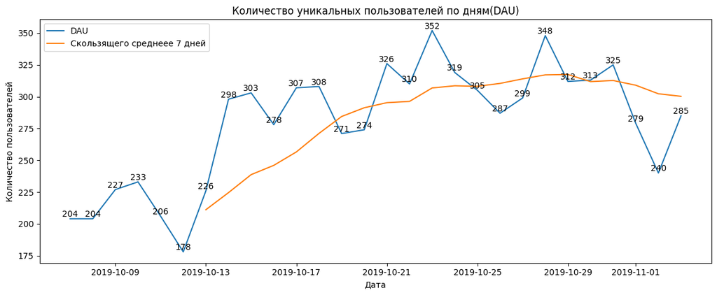

```python
# группировка данных по дню и подсчет количества уникальных пользователей
dau = data_sorted.groupby('date', as_index=False)['user_id'].nunique()

# создание нового DataFrame с колонками 'date' и 'dau'
dau_df = pd.DataFrame({'date': dau['date'], 'dau': dau['user_id']})

# рассчитываем скользящее среднее с окном 7 дней
dau_df['rolling_dau'] = dau_df['dau'].rolling(window=7).mean()


plt.figure( figsize = ( 12, 5))
sns.lineplot( x = 'date', y = 'dau', data = dau_df, label = 'DAU')
sns.lineplot( x = 'date', y = 'rolling_dau', data = dau_df, label = 'Cкользящего среднеее 7 дней')
plt.xlabel('Дата')
plt.xticks( )
plt.title('Количество уникальных пользователей по дням(DAU)')
plt.ylabel('Количество пользователей')

# Добавление значений на график
for i, row in dau_df.iterrows():
    if np.isfinite(row['dau']):
        plt.text(row['date'], row['dau'], str(row['dau']), ha='center', va='bottom')  # DAU values
plt.tight_layout()
plt.show()
```

По гистограмме "Количество уникальных пользователей по дням(DAU)" можно сделать следующие выводы:  
Самый высыкий показатель DAU выходит на 23 октбяря 2019 с количесвом 352

Тенденция роста в начале периода: В начале периода (с 7 по 14 октября) наблюдается тенденция роста активных пользователей, что может указывать на успешные маркетинговые кампании, улучшение продукта или другие факторы, привлекающие пользователей.

Несмотря на некоторые колебания, общая тенденция к росту активных пользователей в течение периода может считаться позитивным показателем особенно за октябрь, хотя стоит насторожиться, что начиная с ноября начинается спад, хотя при этом посмотрев на скользящее среднее пользователей за 7 день, в целом начиная с октября 21 значение не снижалось 275 пользователей

**2.8.Анализ retention rate**

Retention Rate, или коэффициент удержания, показывает, как долго клиенты остаются с компанией. Это один из важнейших показателей «здоровья» бизнеса мы его рассмотрим на 7 день

Соберём следующие функции для анализа данных.

get_profiles() — для создания профилей пользователей,  
get_retention() — для подсчёта Retention Rate,

```python
#добавим к данным таблицу source
data_sorted=pd.merge(data_sorted, source, on='user_id', how='left')
data_sorted.head(5)
```

|  | event_time | event_name | user_id | date | time | time_diff | session_id | source |
| --- | --- | --- | --- | --- | --- | --- | --- | --- |
| 0 | 2019-10-07 13:39:45.989359+00:00 | tips_show | 0001b1d5-b74a-4cbf-aeb0-7df5947bf349 | 2019-10-07 | 13:39:45 | NaN | 1 | other |
| 1 | 2019-10-07 13:40:31.052909+00:00 | tips_show | 0001b1d5-b74a-4cbf-aeb0-7df5947bf349 | 2019-10-07 | 13:40:31 | 45.0 | 1 | other |
| 2 | 2019-10-07 13:41:05.722489+00:00 | tips_show | 0001b1d5-b74a-4cbf-aeb0-7df5947bf349 | 2019-10-07 | 13:41:05 | 34.0 | 1 | other |
| 3 | 2019-10-07 13:43:20.735461+00:00 | tips_show | 0001b1d5-b74a-4cbf-aeb0-7df5947bf349 | 2019-10-07 | 13:43:20 | 135.0 | 1 | other |
| 4 | 2019-10-07 13:45:30.917502+00:00 | tips_show | 0001b1d5-b74a-4cbf-aeb0-7df5947bf349 | 2019-10-07 | 13:45:30 | 130.0 | 1 | other |

```python
def get_profiles(sessions, event_names=[]):

    # сортируем сессии по ID пользователя и дате посещения
    # группируем по ID и находим первые значения session_start и channel
    # столбец с временем первого посещения назовём first_ts
    profiles = (
        data_sorted.sort_values(by=['user_id', 'event_time'])
        .groupby('user_id')
        .agg({'event_time': 'first','source': 'first'})
        .rename(columns={'event_time': 'first_ts'})
        .reset_index()  # возвращаем user_id из индекса
    )

    # определяем дату первого посещения
    # и первый день месяца, в который это посещение произошло
    # эти данные понадобятся для когортного анализа
    profiles['dt'] = profiles['first_ts'].dt.date
    profiles['month'] = profiles['first_ts'].dt.strftime('%Y-%m')

    return profiles
```

Вызовем функцию get_profiles(), чтобы составить профили пользователей по данным сессий из датафрейма sessions:

```python
profiles = get_profiles(data_sorted)
profiles
```

|  | user_id | first_ts | source | dt | month |
| --- | --- | --- | --- | --- | --- |
| 0 | 0001b1d5-b74a-4cbf-aeb0-7df5947bf349 | 2019-10-07 13:39:45.989359+00:00 | other | 2019-10-07 | 2019-10 |
| 1 | 00157779-810c-4498-9e05-a1e9e3cedf93 | 2019-10-19 21:34:33.849769+00:00 | yandex | 2019-10-19 | 2019-10 |
| 2 | 00463033-5717-4bf1-91b4-09183923b9df | 2019-11-01 13:54:35.385028+00:00 | yandex | 2019-11-01 | 2019-11 |
| 3 | 004690c3-5a84-4bb7-a8af-e0c8f8fca64e | 2019-10-18 22:14:05.555052+00:00 | google | 2019-10-18 | 2019-10 |
| 4 | 00551e79-152e-4441-9cf7-565d7eb04090 | 2019-10-25 16:44:41.263364+00:00 | yandex | 2019-10-25 | 2019-10 |
| ... | ... | ... | ... | ... | ... |
| 4288 | ffab8d8a-30bb-424a-a3ab-0b63ebbf7b07 | 2019-10-13 16:11:27.414960+00:00 | yandex | 2019-10-13 | 2019-10 |
| 4289 | ffc01466-fdb1-4460-ae94-e800f52eb136 | 2019-10-07 20:32:49.997044+00:00 | yandex | 2019-10-07 | 2019-10 |
| 4290 | ffcf50d9-293c-4254-8243-4890b030b238 | 2019-10-23 11:51:35.199237+00:00 | google | 2019-10-23 | 2019-10 |
| 4291 | ffe68f10-e48e-470e-be9b-eeb93128ff1a | 2019-10-21 16:39:33.867145+00:00 | yandex | 2019-10-21 | 2019-10 |
| 4292 | fffb9e79-b927-4dbb-9b48-7fd09b23a62b | 2019-10-12 00:57:21.241896+00:00 | google | 2019-10-12 | 2019-10 |

4293 rows × 5 columns

Результат — 4 293 пользовательских профилей, в каждом из которых есть данные о дате первого посещения и рекламном источнике, который мотивировал пользователя посетить мобильное приложение. Такие данные значительно упрощают дальнейший анализ.

Имея готовые профили пользователей, легко узнать количество привлечённых каждым источником посетителей,давйте построим. Достаточно сгруппировать профили по рекламному каналу и посчитать количество уникальных ID функцией nunique():

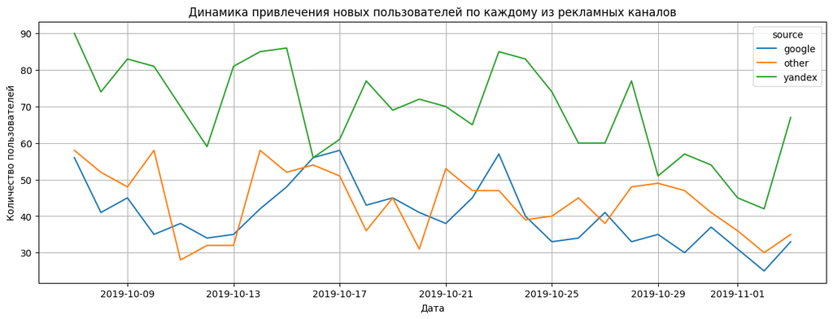

```
        Количество пользователей  Доля пользователей,%
source
google                      1129                 26.30
other                       1230                 28.65
yandex                      1934                 45.05
```

```python
%matplotlib inline

profiles.pivot_table(
    index='dt',  # даты первых посещений
    columns='source',  # источники переходов
    values='user_id',  # ID пользователей
    aggfunc='nunique'  # подсчёт уникальных значений
).plot(figsize=(15, 5), grid=True)
plt.xlabel('Дата')
plt.ylabel('Количество пользователей')
plt.title('Динамика привлечения новых пользователей по каждому из рекламных каналов')
plt.show()


# общее количество уникальных пользователей
total_users = profiles['user_id'].nunique()
# количество уникальных пользователей для каждого источника
users_per_source = profiles.groupby('source')['user_id'].nunique()

# расчет доли пользователей для каждого источника
share_per_source = round(users_per_source / total_users *100,2)
#создание таблицы
source_stats = pd.DataFrame({
    'Количество пользователей': profiles.groupby('source')['user_id'].nunique(),
    'Доля пользователей,%': share_per_source
})

print(source_stats)
```

```python
# Расчет RR

def get_retention(profiles, events, observation_date, horizon_days, dimensions=[], ignore_horizon=False):
    last_suitable_acquisition_date = observation_date
    if not ignore_horizon:
        last_suitable_acquisition_date = observation_date - timedelta(days=horizon_days - 1)

    result_raw = profiles.query('dt <= @last_suitable_acquisition_date')

    result_raw = result_raw.merge(events[['user_id', 'event_time']], on='user_id', how='left')
    result_raw['lifetime'] = (pd.to_datetime(result_raw['event_time']) - pd.to_datetime(result_raw['first_ts'])).dt.days

    def group_by_dimensions(df, dims, horizon_days):
        result = df.pivot_table(index=dims, columns='lifetime', values='user_id', aggfunc='nunique')
        cohort_sizes = df.groupby(dims).agg({'user_id': 'nunique'}).rename(columns={'user_id': 'cohort_size'})
        result = cohort_sizes.merge(result, on=dims, how='left').fillna(0)
        result = result.div(result['cohort_size'], axis=0)
        result = result[['cohort_size'] + list(range(horizon_days))]
        result['cohort_size'] = cohort_sizes['cohort_size']
        return result

    result_grouped = group_by_dimensions(result_raw, dimensions + ['dt'], horizon_days) # Добавлены ключи для группировки
    result_in_time = group_by_dimensions(result_raw, dimensions + ['dt'], horizon_days)

    return result_raw, result_grouped, result_in_time
#     return  result_grouped
```

В качестве горизонта анализа возьмем 7 дней , а моментом анализа будет 03.11.2019. Построим таблицу удержания

```python
observation_date = datetime(2019, 11, 3).date()
rr_raw, rr, rr_in_time= get_retention(profiles, data, observation_date, 7 , dimensions=[], ignore_horizon=False)
rr
```

| dt | cohort_size | 0 | 1 | 2 | 3 | 4 | 5 | 6 |
| --- | --- | --- | --- | --- | --- | --- | --- | --- |
| 2019-10-07 | 204 | 1.0 | 0.122549 | 0.098039 | 0.107843 | 0.053922 | 0.039216 | 0.058824 |
| 2019-10-08 | 167 | 1.0 | 0.161677 | 0.125749 | 0.053892 | 0.041916 | 0.065868 | 0.053892 |
| 2019-10-09 | 176 | 1.0 | 0.073864 | 0.062500 | 0.056818 | 0.068182 | 0.068182 | 0.056818 |
| 2019-10-10 | 174 | 1.0 | 0.091954 | 0.103448 | 0.080460 | 0.097701 | 0.080460 | 0.068966 |
| 2019-10-11 | 136 | 1.0 | 0.088235 | 0.117647 | 0.095588 | 0.088235 | 0.073529 | 0.073529 |
| 2019-10-12 | 125 | 1.0 | 0.128000 | 0.160000 | 0.056000 | 0.064000 | 0.088000 | 0.080000 |
| 2019-10-13 | 148 | 1.0 | 0.128378 | 0.067568 | 0.054054 | 0.067568 | 0.054054 | 0.054054 |
| 2019-10-14 | 185 | 1.0 | 0.113514 | 0.102703 | 0.102703 | 0.081081 | 0.070270 | 0.054054 |
| 2019-10-15 | 186 | 1.0 | 0.139785 | 0.091398 | 0.080645 | 0.053763 | 0.053763 | 0.080645 |
| 2019-10-16 | 166 | 1.0 | 0.126506 | 0.072289 | 0.030120 | 0.048193 | 0.060241 | 0.042169 |
| 2019-10-17 | 170 | 1.0 | 0.141176 | 0.129412 | 0.088235 | 0.088235 | 0.094118 | 0.094118 |
| 2019-10-18 | 156 | 1.0 | 0.083333 | 0.096154 | 0.096154 | 0.057692 | 0.064103 | 0.064103 |
| 2019-10-19 | 159 | 1.0 | 0.094340 | 0.113208 | 0.069182 | 0.025157 | 0.056604 | 0.062893 |
| 2019-10-20 | 144 | 1.0 | 0.104167 | 0.076389 | 0.048611 | 0.069444 | 0.062500 | 0.041667 |
| 2019-10-21 | 161 | 1.0 | 0.093168 | 0.086957 | 0.105590 | 0.043478 | 0.037267 | 0.049689 |
| 2019-10-22 | 157 | 1.0 | 0.114650 | 0.082803 | 0.050955 | 0.038217 | 0.057325 | 0.057325 |
| 2019-10-23 | 189 | 1.0 | 0.095238 | 0.079365 | 0.074074 | 0.052910 | 0.052910 | 0.047619 |
| 2019-10-24 | 162 | 1.0 | 0.104938 | 0.074074 | 0.049383 | 0.061728 | 0.061728 | 0.067901 |
| 2019-10-25 | 147 | 1.0 | 0.088435 | 0.095238 | 0.102041 | 0.095238 | 0.061224 | 0.068027 |
| 2019-10-26 | 139 | 1.0 | 0.151079 | 0.064748 | 0.071942 | 0.086331 | 0.057554 | 0.071942 |
| 2019-10-27 | 139 | 1.0 | 0.071942 | 0.071942 | 0.071942 | 0.079137 | 0.086331 | 0.064748 |
| 2019-10-28 | 158 | 1.0 | 0.094937 | 0.094937 | 0.056962 | 0.056962 | 0.012658 | 0.025316 |

Построим тепловую карту удержания.

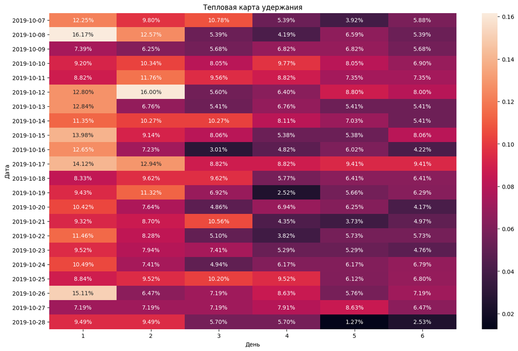

```python
# строим хитмэп без нулевого лайфтайма

plt.figure(figsize=(16,10))  # задаём размер графика
sns.heatmap(
    rr.drop(columns=['cohort_size', 0]),  # удаляем лишние столбцы
    annot=True,  # включаем подписи
    fmt='.2%',  # переводим значения в проценты
)
plt.title('Тепловая карта удержания')  # название графика
plt.xlabel('День')
plt.ylabel('Дата')
plt.show()
```

На тепловой карте видно, что лучше всего удерживаются пользователи, привлеченные 17 октября. К концу анализируемого периода из данной когорты приложением продолжили пользоваться 9,41% пользователей. Также коэффициент удержания для этой когорты относительно стабилен в течении недели. Хуже всего удержание к концу недели у пользователей, привлеченных 28 октября- 2,53%

#### Шаг 3. Основные вопросы исследования

В этом шаге аответим на оснонвые вопросы исследования,а именно:  
-Есть ли связь целевого события просмотра контактов к другим действиям пользователей и выделим оснвные сценарии и по ним построим воронки  
-Есть ли разница между событиям по двум группам пользователей которые смотрели контакты contacts_show и не смотрели.  
Приступим

**3.1.Анализ связи целевого события просмотра контактов к другим действиям пользователей**

Необходимо проанализировать целевое событие просмотра контактов (show_contacts) к другим действиям пользователей:

- провести анализ сессий которые приводят к событию просмотру контактов
- провести Анализ воронок по основным сценариям в разрезе уникальных пользователей

Для этого воспользуемся диаграммой Сэнкея для действий пользователей, это визуализация потоков от одного целевого действия пользователя к другому.

```python
#новый датафрейм,убираем дубликаты
new_df = data_sorted.drop_duplicates(subset=['session_id','event_name'],keep = 'first')
```

```python
def add_features(df):

    """Функция генерации новых столбцов для исходной таблицы

    Args:
        df (pd.DataFrame): исходная таблица.
    Returns:
        pd.DataFrame: таблица с новыми признаками.
    """

    # сортируем по id и времени
    sorted_df = df.sort_values(by=['session_id', 'event_time']).copy()
    # добавляем шаги событий
    sorted_df['step'] = sorted_df.groupby('session_id').cumcount() + 1

    # добавляем узлы-источники и целевые узлы
    # узлы-источники - это сами события
    sorted_df['source'] = sorted_df['event_name']
    # добавляем целевые узлы
    sorted_df['target'] = sorted_df.groupby('session_id')['source'].shift(-1)

    # возврат таблицы без имени событий
    return sorted_df.drop(['event_name'], axis=1)

# преобразуем таблицу
new_df = add_features(new_df)
new_df.head()
```

|  | event_time | user_id | date | time | time_diff | session_id | source | step | target |
| --- | --- | --- | --- | --- | --- | --- | --- | --- | --- |
| 0 | 2019-10-07 13:39:45.989359+00:00 | 0001b1d5-b74a-4cbf-aeb0-7df5947bf349 | 2019-10-07 | 13:39:45 | NaN | 1 | tips_show | 1 | NaN |
| 9 | 2019-10-09 18:33:55.577963+00:00 | 0001b1d5-b74a-4cbf-aeb0-7df5947bf349 | 2019-10-09 | 18:33:55 | 17053.0 | 2 | map | 1 | tips_show |
| 11 | 2019-10-09 18:40:28.738785+00:00 | 0001b1d5-b74a-4cbf-aeb0-7df5947bf349 | 2019-10-09 | 18:40:28 | 300.0 | 2 | tips_show | 2 | NaN |
| 13 | 2019-10-21 19:52:30.778932+00:00 | 0001b1d5-b74a-4cbf-aeb0-7df5947bf349 | 2019-10-21 | 19:52:30 | 4207.0 | 3 | tips_show | 1 | map |
| 15 | 2019-10-21 19:53:38.767230+00:00 | 0001b1d5-b74a-4cbf-aeb0-7df5947bf349 | 2019-10-21 | 19:53:38 | 21.0 | 3 | map | 2 | NaN |

```python
df_comp = new_df.copy()

#Создание словаря с индексами source
def get_source_index(df):

    """Функция генерации индексов source

    Args:
        df (pd.DataFrame): исходная таблица с признаками step, source, target.
    Returns:
        dict: словарь с индексами, именами и соответсвиями индексов именам source.
    """

    res_dict = {}

    count = 0
    # получаем индексы источников
    for no, step in enumerate(df['step'].unique().tolist()):
        # получаем уникальные наименования для шага
        res_dict[no+1] = {}
        res_dict[no+1]['sources'] = df[df['step'] == step]['source'].unique().tolist()
        res_dict[no+1]['sources_index'] = []
        for i in range(len(res_dict[no+1]['sources'])):
            res_dict[no+1]['sources_index'].append(count)
            count += 1

    # соединим списки
    for key in res_dict:
        res_dict[key]['sources_dict'] = {}
        for name, no in zip(res_dict[key]['sources'], res_dict[key]['sources_index']):
            res_dict[key]['sources_dict'][name] = no
    return res_dict


# создаем словарь
source_indexes = get_source_index(df_comp)
```

```python
#Функция случайной генерации цветов
def generate_random_color():

    """Случайная генерация цветов rgba

    Args:

    Returns:
        str: Строка со сгенерированными параметрами цвета
    """

    # сгенерим значение для каждого канала
    r, g, b = np.random.randint(255, size=3)
    return f'rgba({r}, {g}, {b}, 1)'
```

```python
#Создание словаря с соответствиями source: color
def colors_for_sources(mode):

    """Генерация цветов rgba

    Args:
        mode (str): сгенерировать случайные цвета, если 'random', а если 'custom' -
                    использовать заранее подготовленные
    Returns:
        dict: словарь с цветами, соответствующими каждому индексу
    """
    # словарь, в который сложим цвета в соответствии с индексом
    colors_dict = {}

    if mode == 'random':
        # генерим случайные цвета
        for label in df_comp['source'].unique():
            r, g, b = np.random.randint(255, size=3)
            colors_dict[label] = f'rgba({r}, {g}, {b}, 1)'

    elif mode == 'custom':
        # присваиваем ранее подготовленные цвета
        colors = requests.get('https://raw.githubusercontent.com/rusantsovsv/senkey_tutorial/main/json/colors_senkey.json').json()
        for no, label in enumerate(df_comp['source'].unique()):
            colors_dict[label] = colors['custom_colors'][no]

    return colors_dict


# генерю цвета из своего списка
colors_dict = colors_for_sources(mode='custom')
```

```python
def percent_users(sources, targets, values):

    """
    Расчет уникальных id в процентах (для вывода в hover text каждого узла)

    Args:
        sources (list): список с индексами source.
        targets (list): список с индексами target.
        values (list): список с "объемами" потоков.

    Returns:
        list: список с "объемами" потоков в процентах
    """

    # объединим источники и метки и найдем пары
    zip_lists = list(zip(sources, targets, values))

    new_list = []

    # подготовим список словарь с общим объемом трафика в узлах
    unique_dict = {}

    # проходим по каждому узлу
    for source, target, value in zip_lists:
        if source not in unique_dict:
            # находим все источники и считаем общий трафик
            unique_dict[source] = 0
            for sr, tg, vl in zip_lists:
                if sr == source:
                    unique_dict[source] += vl

    # считаем проценты
    for source, target, value in zip_lists:
        new_list.append(round(100 * value / unique_dict[source], 1))

    return new_list
```

```python
def lists_for_plot(source_indexes=source_indexes, colors=colors_dict, frac=10):

    """
    Создаем необходимые для отрисовки диаграммы переменные списков и возвращаем
    их в виде словаря

    Args:
        source_indexes (dict): словарь с именами и индексами source.
        colors (dict): словарь с цветами source.
        frac (int): ограничение на минимальный "объем" между узлами.

    Returns:
        dict: словарь со списками, необходимыми для диаграммы.
    """

    sources = []
    targets = []
    values = []
    labels = []
    link_color = []
    link_text = []

    # проходим по каждому шагу
    for step in tqdm(sorted(df_comp['step'].unique()), desc='Шаг'):
        if step + 1 not in source_indexes:
            continue

        # получаем индекс источника
        temp_dict_source = source_indexes[step]['sources_dict']

        # получаем индексы цели
        temp_dict_target = source_indexes[step+1]['sources_dict']

        # проходим по каждой возможной паре, считаем количество таких пар
        for source, index_source in tqdm(temp_dict_source.items()):
            for target, index_target in temp_dict_target.items():
                # делаем срез данных и считаем количество id
                temp_df = df_comp[(df_comp['step'] == step)&(df_comp['source'] == source)&(df_comp['target'] == target)]
                value = len(temp_df)
                # проверяем минимальный объем потока и добавляем нужные данные
                if value > frac:
                    sources.append(index_source)
                    targets.append(index_target)
                    values.append(value)
                    # делаем поток прозрачным для лучшего отображения
                    link_color.append(colors[source].replace(', 1)', ', 0.2)'))

    labels = []
    colors_labels = []
    for key in source_indexes:
        for name in source_indexes[key]['sources']:
            labels.append(name)
            colors_labels.append(colors[name])

    # посчитаем проценты всех потоков
    perc_values = percent_users(sources, targets, values)

    # добавим значения процентов для howertext
    link_text = []
    for perc in perc_values:
        link_text.append(f"{perc}%")

    # возвратим словарь с вложенными списками
    return {'sources': sources,
            'targets': targets,
            'values': values,
            'labels': labels,
            'colors_labels': colors_labels,
            'link_color': link_color,
            'link_text': link_text}


# создаем словарь
data_for_plot = lists_for_plot()
```

```python
def plot_senkey_diagram(data_dict=data_for_plot):

    """
    Функция для генерации объекта диаграммы Сенкей

    Args:
        data_dict (dict): словарь со списками данных для построения.

    Returns:
        plotly.graph_objs._figure.Figure: объект изображения.
    """

    fig = go.Figure(data=[go.Sankey(
        domain = dict(
          x =  [0,1],
          y =  [0,1]
        ),
        orientation = "h",
        valueformat = ".0f",
        node = dict(
          pad = 50,
          thickness = 15,
          line = dict(color = "black", width = 0.1),
          label = data_dict['labels'],
          color = data_dict['colors_labels']
        ),
        link = dict(
          source = data_dict['sources'],
          target = data_dict['targets'],
          value = data_dict['values'],
          label = data_dict['link_text'],
          color = data_dict['link_color']
      ))])
    fig.update_layout(title_text="Sankey Diagram", font_size=10, width=1000, height=1020)

    # возвращаем объект диаграммы
    return fig


# сохраняем диаграмму в переменную
senkey_diagram = plot_senkey_diagram()
```

```python
senkey_diagram.update_layout(title_text="Потоки пользователей мобильного приложения")
senkey_diagram.show()


# Создаем диаграмму
senkey_diagram = plot_senkey_diagram()
```

[interactive chart not shown]

Построив диаграмму Сэнкей, мы сразу видим наше целевое действие show_contacts (посмотр номера телефона) 44,9% это может говоритт что пользователь сразу прошел по полученной ссылки и просотрел контакт, но для последуещего анализа просмотрев диаграмму выберем для воронок следующие 3 сценария:  
1.search (поиск по сайту) - map (просмотр карты объявления) - show_contacts (посмотр номера телефона)  
2.search (поиск по сайту) - photos_show (просмотр фотографий в объявлении) - show_contacts (посмотр номера телефона)  
3.map (просмотр карты объявления)- tips_show (увидел рекомендованные объявления) - show_contacts (посмотр номера телефона)

**Анализ воронок по основным сценариям в разрезе уникальных пользователей**

Начнем анализ отобранных сценариев, создадим функцию для просмотра графика воронки

```python
def analyze_scenario(event_name_1, event_name_2, event_name_3, data_sorted):
    # вычисляем уникальных пользователей для первого события
    first = data_sorted[data_sorted['event_name'] == event_name_1]['user_id'].unique()
    first_count = len(first)

    # вычисляем уникальных пользователей для второго события, которые присутствуют в первом событии
    second = (data_sorted[(data_sorted['event_name'] == event_name_2) & (data_sorted['user_id'].isin(first))]['user_id']).unique()
    second_count = len(second)

    # вычисляем уникальных пользователей для третьего события, которые присутствуют во втором событии
    third = (data_sorted[(data_sorted['event_name'] == event_name_3) & (data_sorted['user_id'].isin(second))]['user_id']).unique()
    third_count = len(third)

    # создаем DataFrame с результатами
    df_funnel = pd.DataFrame({'event_name': [event_name_1, event_name_2, event_name_3],
                              'users_count': [first_count, second_count, third_count]})
    df_funnel['%'] = round((df_funnel['users_count'] * 100 / df_funnel['users_count'].shift(1)).fillna(100), 2)

    # строим график воронки
    funnel = dict(
        number=df_funnel['users_count'],
        stage=df_funnel['event_name']
    )
    fig = px.funnel(funnel, x='number', y='stage', title='Воронка пользователей')
    # обновляем подпись оси y
    fig.update_layout(yaxis_title='Событие')
    fig.show()

    print(df_funnel)
```

```python
# сценарий 1
event_name_1 = 'search'
event_name_2 = 'map'
event_name_3 = 'show_contacts'
analyze_scenario(event_name_1, event_name_2, event_name_3, data_sorted)
```

[interactive chart not shown]

```
      event_name  users_count       %
0         search         1666  100.00
1            map          463   27.79
2  show_contacts           92   19.87
```

```python
# сценарий 2
event_name_1 = 'search'
event_name_2 = 'photos_show'
event_name_3 = 'show_contacts'
analyze_scenario(event_name_1, event_name_2, event_name_3, data_sorted)
```

[interactive chart not shown]

```
      event_name  users_count       %
0         search         1666  100.00
1    photos_show          647   38.84
2  show_contacts          192   29.68
```

```python
# сценарий 3
event_name_1 = 'map'
event_name_2 = 'tips_show'
event_name_3 = 'show_contacts'
analyze_scenario(event_name_1, event_name_2, event_name_3, data_sorted)
```

[interactive chart not shown]

```
      event_name  users_count       %
0            map         1456  100.00
1      tips_show         1352   92.86
2  show_contacts          275   20.34
```

**3.2. Расчет и сравнение относительной частоты событий между двумя группами пользователей:**  
--1 группа пользователей, которые смотрели контакты show_contacts  
--2 группа пользователей, которые не смотрели контакты show_contacts

Проведем анализ по относительной частоты событий в разрезе двух групп которые смотрели contacts_show и не смотрели

```python
# группировка данных по user_id и сбор уникальных событий
new_data = data.groupby('user_id')['event_name'].agg(list).reset_index()
#new_data = data.groupby('user_id')['event_name'].agg(lambda x: list(set(x))).reset_index()

# фильтрация пользователей, совершивших событие "show_contacts"
users_with_show_contacts = new_data[new_data['event_name'].apply(lambda x: 'show_contacts' in x)]

# фильтрация пользователей, не совершивших событие "show_contacts"
users_without_show_contacts = new_data[~new_data['event_name'].apply(lambda x: 'show_contacts' in x)]

display(users_with_show_contacts.head(3))
display(users_without_show_contacts.head(3))
```

|  | user_id | event_name |
| --- | --- | --- |
| 1 | 00157779-810c-4498-9e05-a1e9e3cedf93 | [search, search, search, photos_show, photos_s... |
| 4 | 00551e79-152e-4441-9cf7-565d7eb04090 | [show_contacts, contacts_call, search, show_co... |
| 6 | 005fbea5-2678-406f-88a6-fbe9787e2268 | [show_contacts, show_contacts, show_contacts, ... |

|  | user_id | event_name |
| --- | --- | --- |
| 0 | 0001b1d5-b74a-4cbf-aeb0-7df5947bf349 | [tips_show, tips_show, tips_show, tips_show, t... |
| 2 | 00463033-5717-4bf1-91b4-09183923b9df | [photos_show, photos_show, photos_show, photos... |
| 3 | 004690c3-5a84-4bb7-a8af-e0c8f8fca64e | [search, search, map, search, search, search, ... |

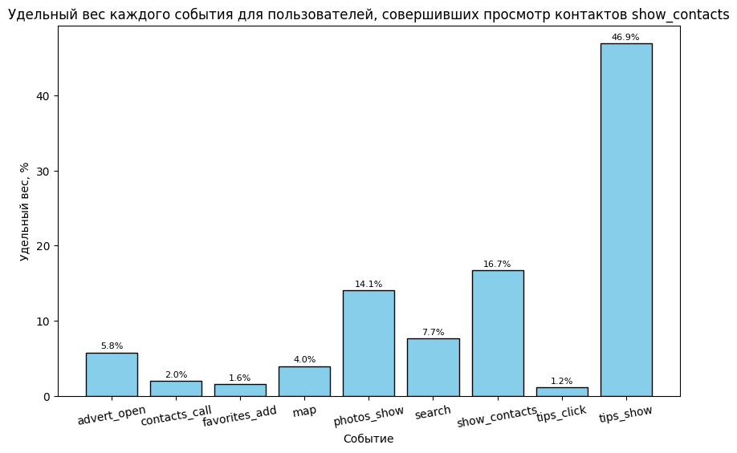

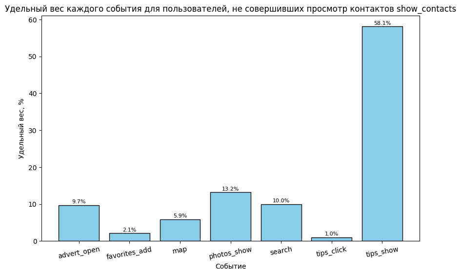

```python
#построение данных для пользователей, совершивших просмотр контактов show_contacts
# разделение данных 'event_name' на столбцы
exploded_events = users_with_show_contacts.explode('event_name')

# подстчет количеств каждого события
event_frequency = exploded_events['event_name'].value_counts().reset_index()
event_frequency.columns = ['event_name', 'frequency']

# сортировка по алфавиту для графика
event_frequency = event_frequency.sort_values(by='event_name')

# общая сумма событий
total_events = event_frequency['frequency'].sum()

# расчет удельного веса каждого события
event_frequency['relative_frequency'] = round(event_frequency['frequency'] / total_events*100,1)

# построение гистограммы
plt.figure(figsize=(10, 6))
bars = plt.bar(event_frequency['event_name'], event_frequency['relative_frequency'], color='skyblue', edgecolor='black')

# Добавление значений удельного веса над каждым столбцом
for bar in bars:
    yval = bar.get_height()
    plt.text(bar.get_x() + bar.get_width()/2, yval + 0.5, f"{yval}%", ha='center', fontsize=8)

plt.xlabel('Событие')
plt.ylabel('Удельный вес, %')
plt.title('Удельный вес каждого события для пользователей, совершивших просмотр контактов show_contacts')
plt.xticks(rotation=10)
plt.show()


#построение данных для пользователей, не совершивших просмотр контактов show_contacts
# разделение данных 'event_name' на столбцы
exploded_events = users_without_show_contacts.explode('event_name')

# подстчет количеств каждого события
event_frequency = exploded_events['event_name'].value_counts().reset_index()
event_frequency.columns = ['event_name', 'frequency']

# сортировка по алфавиту для графика
event_frequency = event_frequency.sort_values(by='event_name')

# общая сумма событий
total_events = event_frequency['frequency'].sum()

# расчет удельного веса каждого события
event_frequency['relative_frequency'] = round(event_frequency['frequency'] / total_events*100,1)

# построение гистограммы
plt.figure(figsize=(10, 6))
bars = plt.bar(event_frequency['event_name'], event_frequency['relative_frequency'], color='skyblue', edgecolor='black')

# добавление значений процента над каждым столбцом
for bar in bars:
    yval = bar.get_height()
    plt.text(bar.get_x() + bar.get_width()/2, yval + 0.5, f"{yval}%", ha='center', fontsize=8)

plt.xlabel('Событие')
plt.ylabel('Удельный вес, %')
plt.title('Удельный вес каждого события для пользователей, не совершивших просмотр контактов show_contacts')
plt.xticks(rotation=10)
plt.show()
```

Построив два графика:  
-Удельный вес каждого события для пользователей, совершивших просмотр контактов show_contacts  
-Удельный вес каждого события для пользователей, не совершивших просмотр контактов show_contacts

Можно сделать следующие выводы:  
Для Группы пользователей которые смотрели контакты (show_contacts) tips_show на первом месте с долей 46,9%, затем идет photos_show с весом 14,1% и поиск с весом 7,7%. А те пользователи которые не смотрели контакты (show_contacts) на первом месте так же tips_show с весом 58,1%, на втором 13,2% просмотр фотографий и поиск весит 10%.

#### Шаг 4. Проверка гипотез.

**Первая гипотеза:**  
Конверсия в просмотры контактов может быть различной между пользователями, которые совершают действия tips_show и tips_click, и пользователями, которые совершают только действие tips_show.  
*H0 (нулевая гипотеза)*: Конверсия в просмотры контактов одинакова у пользователей, которые совершают действия tips_show и tips_click, и у пользователей, которые совершают только действие tips_show.  
*H1 (альтернативная гипотеза)*: Конверсия в просмотры контактов различается у пользователей, которые совершают действия tips_show и tips_click, и у пользователей, которые совершают только действие tips_show.

Проведем статистический Z-тест для проверки гипотезы о равенстве конверсий между двумя группами.  
Z-оценка в данном контексте является стандартизированным значением, которое показывает, насколько выборочная разница в пропорциях (конверсии в данном случае) отклоняется от ожидаемой разницы в случае, если нулевая гипотеза верна.  
Значение p-value (уровень значимости) показывает вероятность получить наблюдаемое различие в пропорциях, равное или больше, чем фактическое, при условии, что нулевая гипотеза верна.

Если p-value меньше выбранного уровня значимости (обычно 0.05), то мы отвергаем нулевую гипотезу в пользу альтернативной. В противном случае, мы не можем отвергнуть нулевую гипотезу.

```python
# разделяем пользователей на две группы: те, кто совершал 'tips_show' и 'tips_click', и те, кто совершал только 'tips_show'
users_with_click = set(data_sorted[data_sorted['event_name'] == 'tips_click']['user_id'].unique())
users_with_show = set(data_sorted[data_sorted['event_name'] == 'tips_show']['user_id'].unique())

# пользователи, совершавшие оба действия
users_with_both = users_with_click.intersection(users_with_show)

# подсчитываем количество пользователей каждой группы, которые совершили просмотр контактов ('show_contacts')
users_with_contacts_click = len(data_sorted[(data_sorted['event_name'] == 'show_contacts')
                                            & data_sorted['user_id'].isin(users_with_both)]['user_id'].unique())
users_with_contacts_show = len(data_sorted[(data_sorted['event_name'] == 'show_contacts')
                                           & data_sorted['user_id'].isin(users_with_show)]['user_id'].unique())

# подсчитываем общее количество пользователей в каждой группе
total_users_with_click = len(users_with_both)
total_users_only_show = len(users_with_show)
total_users_only_tip_show = total_users_only_show-total_users_with_click

# подсчитываем конверсию в просмотры контактов для каждой группы
conversion_with_click = round(users_with_contacts_click / total_users_with_click*100,2)
conversion_only_show = round(users_with_contacts_show / total_users_only_show*100,2)

#Z-теста: количество успехов (просмотров контактов) и общее количество пользователей в каждой группе
successes = [users_with_contacts_click, users_with_contacts_show]
nobs = [total_users_with_click, total_users_only_tip_show]

# проведение Z-теста
stat, p_value = proportions_ztest(successes, nobs)

# выводим результаты
print("Конверсия в просмотры контактов для пользователей, совершавших 'tips_show' и 'tips_click' %:", conversion_with_click)
print("Конверсия в просмотры контактов для пользователей, совершавших только 'tips_show' %:", conversion_only_show)
print('p-value:',p_value)
print("Successes:", successes)
print("Nobs:", nobs)

# сравниваем p-value с выбранным уровнем значимости (обычно 0.05) для принятия решения о нулевой гипотезе
if p_value < 0.05:
    print("Отвергаем нулевую гипотезу")
else:
    print("Не отвергаем нулевую гипотезу")
```

```
Конверсия в просмотры контактов для пользователей, совершавших 'tips_show' и 'tips_click' %: 30.64
Конверсия в просмотры контактов для пользователей, совершавших только 'tips_show' %: 18.42
p-value: 7.25185465383365e-05
Successes: [91, 516]
Nobs: [297, 2504]
Отвергаем нулевую гипотезу
```

**Вторая гипотеза:**  
Конверсия в просмотры контактов у пользователей, пришедших с сервиса Yandex, выше, чем у пользователей, пришедших с других сервисов.  
*H0 (нулевая гипотеза)*: Конверсия в просмотры контактов одинакова у пользователей, пришедших с сервиса Yandex, и у пользователей, пришедших с других сервисов.  
*H1 (альтернативная гипотеза)*: Конверсия в просмотры контактов выше у пользователей, пришедших с сервиса Yandex, по сравнению с пользователями, пришедшими с других сервисов.

```python
# разделяем пользователей на две группы: те, кто пришел с сервиса Yandex, и те, кто пришел с других сервисов
users_yandex = set(data_sorted[data_sorted['source'] == 'yandex']['user_id'].unique())
users_other = set(data_sorted[data_sorted['source'] != 'yandex']['user_id'].unique())

# подсчитываем количество пользователей в каждой группе
total_users_yandex = len(users_yandex)
total_users_other = len(users_other)

# подсчитываем количество пользователей каждой группы, которые совершили просмотр контактов ('show_contacts')
users_with_contacts_yandex = len(data_sorted[(data_sorted['event_name'] == 'show_contacts') & data_sorted['user_id'].isin(users_yandex)]['user_id'].unique())
users_with_contacts_other = len(data_sorted[(data_sorted['event_name'] == 'show_contacts') & data_sorted['user_id'].isin(users_other)]['user_id'].unique())

# подсчитываем конверсию в просмотры контактов для каждой группы
conversion_yandex = round(users_with_contacts_yandex / total_users_yandex *100,2)
conversion_other = round(users_with_contacts_other / total_users_other*100,2)

# выводим результаты
print("Конверсия в просмотры контактов для пользователей, пришедших с сервиса Yandex %:", conversion_yandex)
print("Конверсия в просмотры контактов для пользователей, пришедших с других сервисов %:", conversion_other)

# ароводим Z-тест для проверки статистической значимости различий в конверсии между группами
count = np.array([users_with_contacts_yandex, users_with_contacts_other])
nobs = np.array([total_users_yandex, total_users_other])
z_score, p_value = proportions_ztest(count, nobs)

# выводим результаты Z-теста
print("Z-оценка:", z_score)
print("p-value:", p_value)

# сравниваем p-value с выбранным уровнем значимости (обычно 0.05) для принятия решения о нулевой гипотезе
if p_value < 0.05:
    print("Отвергаем нулевую гипотезу")
else:
    print("Не отвергаем нулевую гипотезу")
```

```
Конверсия в просмотры контактов для пользователей, пришедших с сервиса Yandex %: 24.72
Конверсия в просмотры контактов для пользователей, пришедших с других сервисов %: 21.32
Z-оценка: 2.634386714554908
p-value: 0.008428942598692543
Отвергаем нулевую гипотезу
```

Из результатов вычислений мы видим следующее:  
Конверсия в просмотры контактов для пользователей, пришедших с сервиса Yandex, составляет приблизительно 24.7%.  
Конверсия в просмотры контактов для пользователей, пришедших с других сервисов, составляет приблизительно 21.3%.  
Z-оценка равна 2.63, а p-value равно 0.0084.

Так как p-value меньше выбранного уровня значимости 0.05, мы **отвергаем нулевую гипотезу** о том, что конверсия в просмотры контактов одинакова у пользователей, пришедших с сервиса Yandex, и у пользователей, пришедших с других сервисов. Это означает, что существует статистически значимое различие в конверсии между этими двумя группами пользователей.

Исходя из этого, мы можем сделать вывод, что конверсия в просмотры контактов выше у пользователей, пришедших с сервиса Yandex, по сравнению с пользователями, пришедшими с других сервисов.

#### Шаг 5. Выводы.

Проведя анализ, можно сделать следуюшие выводы:

В первом шаге были изучены данные, произвели смену названий столбцов на нижний регистр. Добавили необходимые столбцы с датами для дальнейшего изучения данных. Проверили данные на дубликаты.

Самый высыкий показатель DAU (Daily Active Users) был 23 октября 2019 с количесвом 352.  
Лучше всего удерживаются пользователи, привлеченные 17 октября. К концу анализируемого периода из данной когорты приложением продолжили пользоваться 9,41% пользователей. Также коэффициент удержания для этой когорты относительно стабилен в течении недели. Хуже всего удержание к концу недели у пользователей, привлеченных 28 октября- 2,53%

Построив диаграмму Сэнкей было отобрано для воронок следующие 3 сценария:  
1.search (поиск по сайту) - map (просмотр карты объявления) - show_contacts (посмотр номера телефона)  
2.search (поиск по сайту) - photos_show (просмотр фотографий в объявлении) - show_contacts (посмотр номера телефона)  
3.map (просмотр карты объявления)- tips_show (увидел рекомендованные объявления) - show_contacts (посмотр номера телефона)

Из данных сценаиев - Сценарий 2 выглядит наиболее удачным, с наименьшими потерями пользователей между этапами с результатом 29.68%.

Вторая гипотеза:  
*Конверсия в просмотры контактов у пользователей, пришедших с сервиса Yandex, выше, чем у пользователей, пришедших с других сервисов*.  
**H0 (нулевая гипотеза)**: Конверсия в просмотры контактов одинакова у пользователей, пришедших с сервиса Yandex, и у пользователей, пришедших с других сервисов.  
**H1 (альтернативная гипотеза)**: Конверсия в просмотры контактов выше у пользователей, пришедших с сервиса Yandex, по сравнению с пользователями, пришедшими с других сервисов.  
p-value равно 0.0084, **отвергаем нулевую гипотезу** о том, что конверсия в просмотры контактов одинакова у пользователей, пришедших с сервиса Yandex, и у пользователей, пришедших с других сервисов. Это означает, что существует статистически значимое различие в конверсии между этими двумя группами пользователей.  
Исходя из этого, мы можем сделать вывод, что конверсия в просмотры контактов выше у пользователей, пришедших с сервиса Yandex, по сравнению с пользователями, пришедшими с других сервисов.

Получив, данные результы можно сформулировать несколько гипотез о том, как можно улучшить приложение с точки зрения пользовательского опыта. Вот несколько идей:

**Оптимизация процесса поиска и просмотра объявлений**: Учитывая, что большинство пользователей начинают свой путь с поиска объявлений, важно сделать этот процесс максимально интуитивным и эффективным. Можно предложить функционал фильтрации результатов поиска, улучшить рекомендации и алгоритмы сортировки объявлений.  
**Улучшение пользовательского интерфейса для просмотра фотографий**: Учитывая, что просмотр фотографий в объявлениях имеет высокую конверсию в просмотры контактов, можно улучшить пользовательский интерфейс для этой функции. Например, сделать просмотр фотографий более удобным и привлекательным, возможно, добавив возможность увеличения изображений или слайд-шоу.  
**Разработка персонализированных рекомендаций и уведомлений**: Используя данные о поведении пользователей, можно предлагать персонализированные рекомендации и уведомления, например, на основе предпочтений пользователя или его предыдущих действий в приложении. Это может помочь улучшить вовлеченность пользователей и повысить конверсию на различных этапах пользовательского пути.  
Работа с этими гипотезами может помочь сделать мобильное приложение более привлекательным и удобным для пользователей.